# FE515 2022A Assignment 2

Yufu Liao

03/11/2023

# Question 1: (50 points)

## 1.1

Find the attached JPM.csv file. Use as.Date() function to change the first column to Date object.

```r
jpm <- read.csv("JPM.csv")
jpm$X <- as.Date(jpm$X, origin = "2023/01/01")
jpm[1:10,]
```

|  | X | JPM.Open | JPM.High | JPM.Low | JPM.Close | JPM.Volume | JPM.Adjusted |
| --- | --- | --- | --- | --- | --- | --- | --- |
| 1 | 2023-01-02 | 48.00 | 48.37 | 47.59 | 48.07 | 14244700 | 32.52235 |
| 2 | 2023-01-03 | 48.05 | 48.55 | 47.75 | 48.19 | 9471500 | 32.60353 |
| 3 | 2023-01-04 | 48.17 | 48.25 | 47.63 | 47.79 | 10760500 | 32.33291 |
| 4 | 2023-01-05 | 47.57 | 48.06 | 47.32 | 47.95 | 8239200 | 32.44115 |
| 5 | 2023-01-06 | 47.90 | 48.11 | 47.36 | 47.75 | 9276700 | 32.30586 |
| 6 | 2023-01-07 | 47.47 | 48.12 | 47.44 | 48.10 | 15597000 | 32.54265 |
| 7 | 2023-01-08 | 48.00 | 48.42 | 47.94 | 48.31 | 8049200 | 32.68473 |
| 8 | 2023-01-09 | 48.10 | 48.26 | 47.90 | 47.99 | 10646700 | 32.46823 |
| 9 | 2023-01-10 | 48.16 | 48.46 | 48.10 | 48.39 | 8696500 | 32.73885 |
| 10 | 2023-01-11 | 48.65 | 48.89 | 48.12 | 48.43 | 16291400 | 32.76591 |

## 1.2

Plot the adjusted close price against the date object (i.e. date object as x-axis and close price as y-axis) in red line (require no points). Set the title as JPM, the label for x-axis as Date and the label for y-axis as Adjusted Close Price.

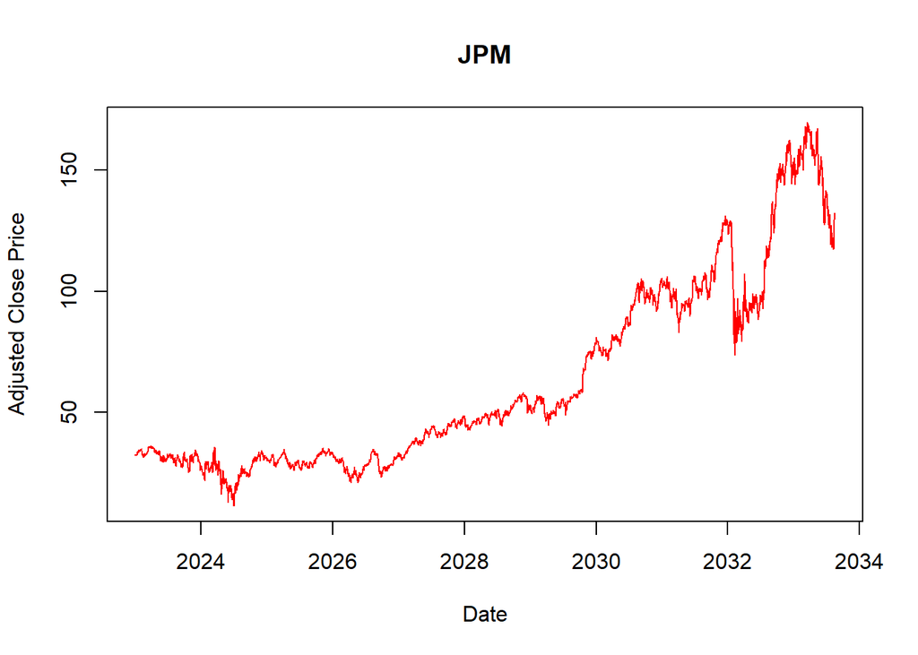

```r
plot(jpm$X, jpm$JPM.Adjusted,
     main = "JPM",
     xlab = "Date",
     type = "l",
     ylab = "Adjusted Close Price",
     col = "red"
)
```

## 1.3

Create a scatter plot of close price against open price (i.e. open prices as x-axis, and close prices as y-axis). Set the x label as ”Open Price” and y label as ”Close Price”.

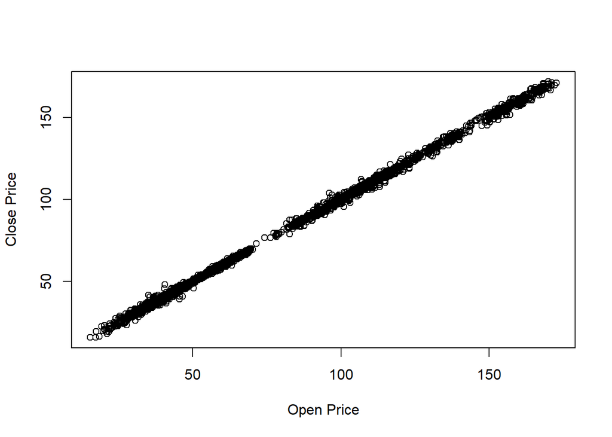

```r
plot(jpm$JPM.Open, jpm$JPM.Close,
     xlab = "Open Price",
     ylab = "Close Price"
)
```

## 1.4

Use cut() function to divide adjusted close price into 4 intervals. Generate a barplot for the frequencies of these intervals.

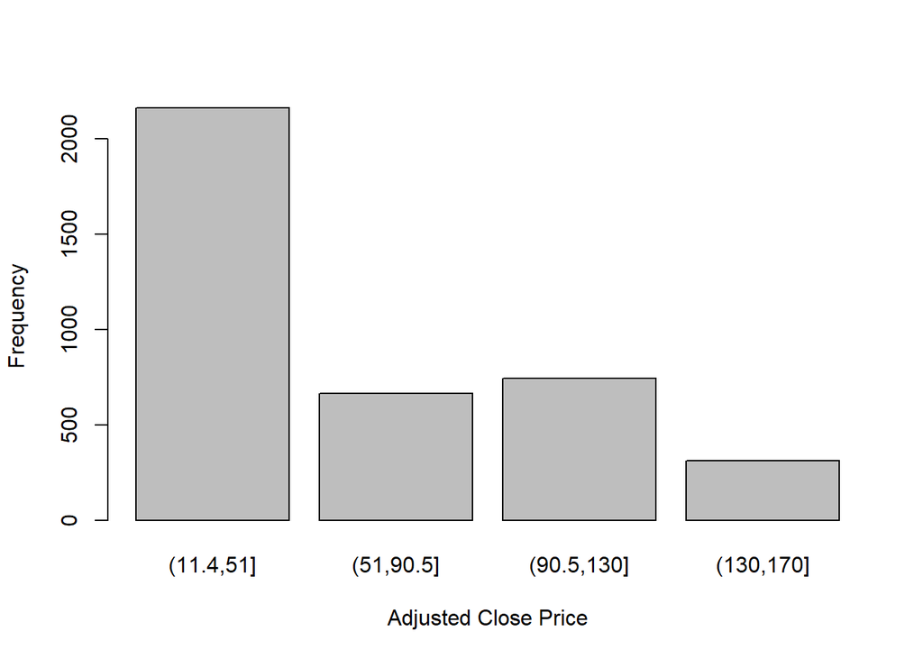

```r
cut_close <- cut(jpm$JPM.Adjusted, 4)
barplot(table(cut_close), xlab = "Adjusted Close Price", ylab = "Frequency")
```

## 1.5

Generate a boxplot of volume against the 4 intervals of adjusted close prices.

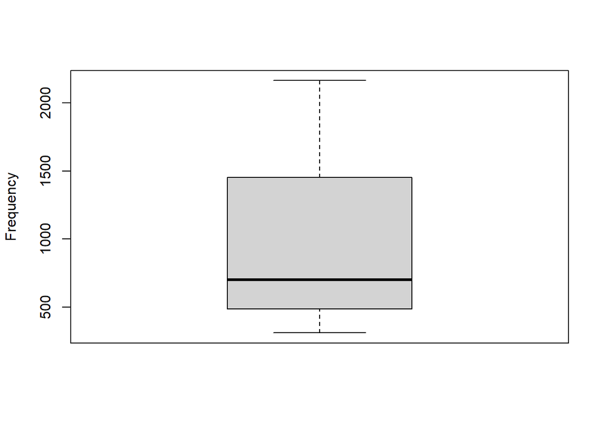

```r
boxplot(table(cut_close), ylab = "Frequency")
```

## 1.6

Use par() function to create a picture of 4 subplots. Gather the 4 figures from 1.2 - 1.5 into ONE single picture. Please arrange the 4 subplots into a 2 by 2 frame, i.e. a frame consists of 2 columns and 2 rows. (Hint. `par(mfrow = c(1,3))` will create a picture of three subplots. In the picture, the subplots are arranged into a 1 by 3 frame.)

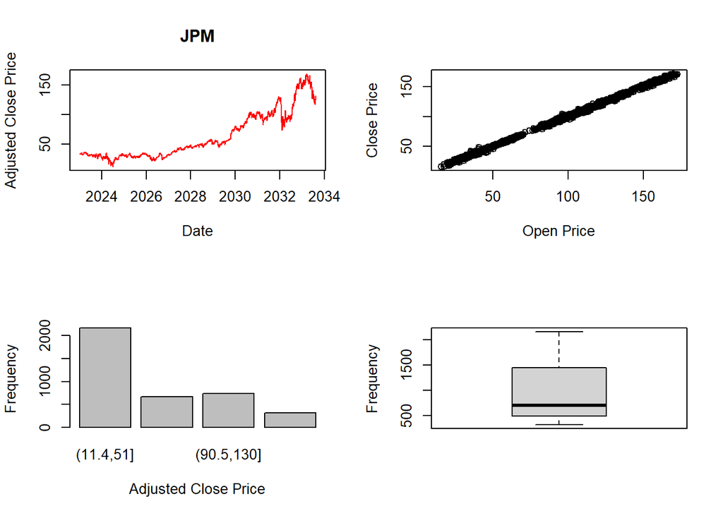

```r
par(mfrow = c(2, 2))
plot(jpm$X, jpm$JPM.Adjusted,
     main = "JPM",
     xlab = "Date",
     type = "l",
     ylab = "Adjusted Close Price",
     col = "red"
)
plot(jpm$JPM.Open, jpm$JPM.Close,
     xlab = "Open Price",
     ylab = "Close Price"
)
barplot(table(cut_close), xlab = "Adjusted Close Price", ylab = "Frequency")
boxplot(table(cut_close), ylab = "Frequency")
```

# Question 2

Estimate the volume of the unit sphere (which is just 4π/3) by simulation.

```r
seed <- 1
rnd <- function(n){
  m <- 2 ^ 31 - 1
  a <- 7 ^ 5
  b <- 0

  x <- rep(NA, n)
  x[1] <- (a * seed + b) %% m

  for(i in 1:(n - 1)){
    x[i + 1] <- (a * x[i] + b) %% m
  }
  seed <<- x[n]

  return(x / m)
}

num.total <- 100000
x <- rnd(num.total)
y <- rnd(num.total)
z <- rnd(num.total)

num.inner <- sum(x ^ 2 + y ^ 2 + z ^ 2 <= 1)
volume.eighth <- num.inner / num.total
(volume.sphere <- 8 * volume.eighth)
```

```
## [1] 4.16512
```

# Question 3

## 3.1

Implement a Linear Congruential Generator (LCG)

```r
LCG <- function(n) {
  m <- 244944
  a <- 1597
  b <- 51749

  x <- rep(NaN, n)
  x[1] <- (a * 1 + b) %% m

  for(i in 1:(n - 1)) {
    x[i + 1] <- (a * x[i] + b) %% m
  }

  return(x / m)
}
```

## 3.2

Use the LCG in the previous problem, generate 10000 random numbers from chi-square distribution with 10 degrees of freedom (i.e. `df = 10`), and assign to a variable. (Hint.: `X = qnorm(LCG(10000))` will generate a sample of 10000 numbers X which follows normal distribution. For chi-square case, please consider another function `qchisq()`.)

```r
X <- qchisq(LCG(10000), df = 10)
head(X)
```

```
## [1]  6.382024  3.042432  9.342521 13.756028 11.820942  9.921533
```

## 3.3

Visualize the resulting sample from 3.2 using a histogram with 40 bins.

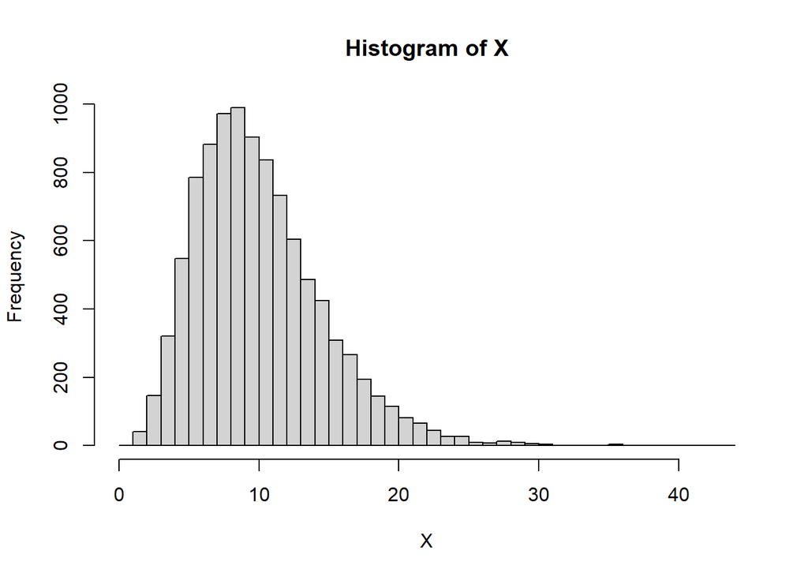

```r
hist(X, nclass = 40)
```